# Chapter 2

# Types of Variables and Levels of Measurement

# Let’s Introduce (or reintroduce) Some Terms

## Variable

A characteristic that describes people, objects, or places and takes on multiple values in a sample or a population.

Or in short…. it is something that varies or changes.

Examples? Any guesses?

- The amount of crime across different states.
- The number of water molecules between different lakes.
- The height differences between classmates.

## Constant

A characteristic that describes people, objects, or places and takes on only one value in a sample or a population.

Or in short (again)…. it is something the does not vary.

Examples? Any guesses?

- Asking everyone in class if they are taking statistics… all the answers would be “Yes!”
- Speed of light in vacuum (i.e., devoid of matter, like outer space) will always be exactly 299,792,458 m/s.
- The depth of Mariana Trench will always be 35,814 feet.

## Units of Analysis

The object or target of a research study.

Or simply the something that a researcher gathers or studies.

In criminology our unit of analysis are usually people like correctional officers, police officers, and judges.

We can also use a larger units of analysis, often called systems, like correctional institutes, police departments, and courts.

## More About Variables

[More Kylo Ren GIF](https://tenor.com/view/more-kylo-ren-adam-driver-screaming-star-wars-gif-17734637)from [More GIFs](https://tenor.com/search/more-gifs)

image by tenor

## Dependent Variables

The phenomena that the researcher is studying, trying explain or predict.

Or more simply…. the **outcome** that changes.

Our most common dependent variable is….. what do you think?

- Crime!!!!!!!!

## Independent Variables

A factor of characteristic that is used to try to explain or predict the dependent variable.

Or more simply… the characteristic that **In**fluences

These range to all sorts of things (e.g., hunger, being inebriated, having mental disposition like psychopathy) and are most commonly the backbone of a theory.

## Empirical

Having the qualities of being measurable, observable, or tangible.

Empirical phenomena are detectable with senses such as touch, sight, or hearing and they give rise to questions about the underlying forces driving them.

## Pop Quiz

Identify the correct choice after reading the question below.

A police department collected data on gun crime incidents within each city in Nebraska, they hypothesized that a change would occur after the a recent protest within the city of Omaha.

What response best describe gun crime incidents

A.) it is an independent variable and a constant  
B.) it is an independent variable and not a constant  
C.) it is the dependent variable and not a constant  
D.) it is the dependent variable and a constant

`01:00`

## Relationships Between Variables: A Cautionary Note

Independent and dependent variables are not synonymous with cause and effect.

An independent variable might be related (or correlated with) a dependent variable but this does not mean that are causally related.

# Ok, then how do we determine a causual relationship?

## What is a causal relationship?

A Causal effect is when variation in one phenomena the independent variable leads to variation in another phenomena the dependent variable..

$$X-> Y$$

## Temporal Ordering or Time Order

The independent variable must occur prior to dependent variable.

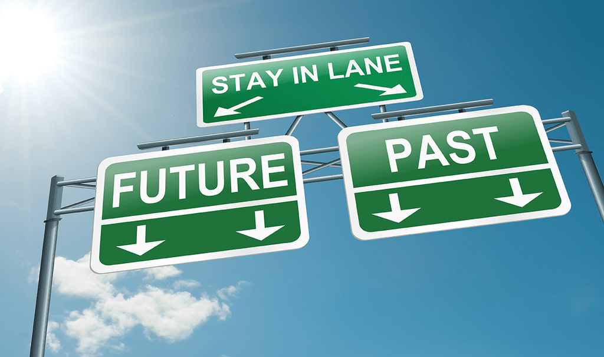

image: Physics World

## Empirical Relationship or Association

The independent and dependent variable must have some observed association.

In other words, if there is an change in one variable (X), there must be a change in another variable (Y).

## Non-spuriousness or Controlling for Confounders

The relationship between the independent variable and the dependent variable is not the result of a third un-accounted variable.

This generally occurs due to omitted variable bias.

For example, the association between an increase in ice cream sales and increase in crime.

## What is the omitted variable?

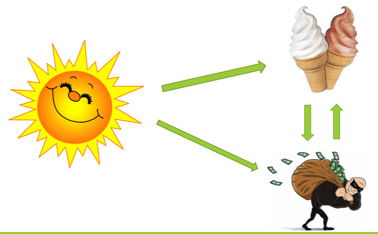

image: outsmarting statistics

## Recap

Variables

Constants

Three Rule for Causality

## Levels of Measurement

A variables specific type or classification.

There are two classes of variables - continuous or quantitative and categorical or qualitative.

Wihtin the two classes there are Four Levels:

1.) Nominal  
2.) Ordinal  
3.) Interval  
4.) Ratio

## Nominal Variables

Categorical level of measurement

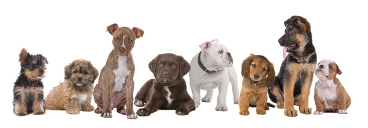

(image: Depositphotos )

## Ordinal Variables

Categorical but acts quantitative because of rank.

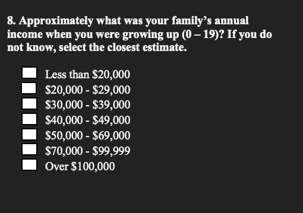

## Interval Variables

Continuous but lacks a fixed zero point.

[figure not shown]

image: Research Method

## Ratio Variables

Continuous and has an absolute zero point.

[figure not shown]

## Attributes of Measurements

Mutually exclusive attributes

Exhaustive attributes

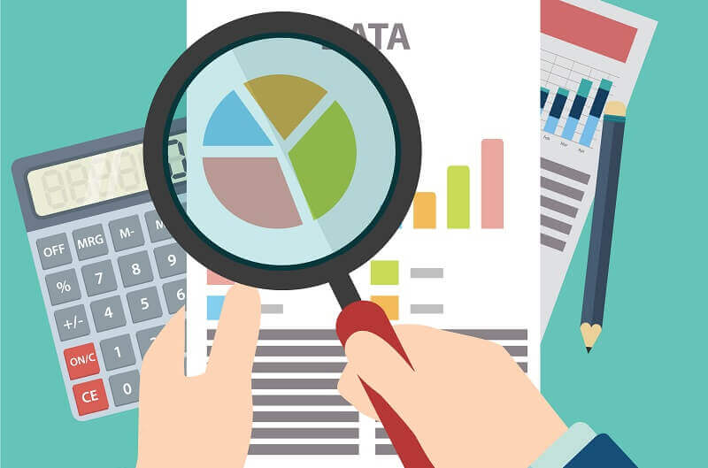

image: heflo

## Pop Quiz

You are a researcher at a think-tank compiling data on the amount of violent incidents in order to create a rank the most dangerous cities in America. What level of measurement is your dependent variable?

A.) Ratio  
B.) Interval  
C.) Ordinal  
D.) Nominal

`01:00`

## Have a great day!!!!

[figure not shown]

image: giphy